# Experiment 3

Eva Viviani

2/5/2021

## beta estimates from Ramscar’s pilot

Our predicted effect sizes for the 2AFC tasks are based on data from an unpublished study that replicates Ramscar et al., (2010) effects. For the contingency judgment task instead we use our own pilot data.

We use for further analysis of the Bayes Factor the betas extracted from the model.

These are the betas of the models ran on Ramscar’s pilot data that we specify as theory in our Bayes Factor function:

- frequency: $\beta$ =-1.7 Note that this is negative.
- learning: $\beta$ =0.66
- interaction between learning and frequency: $\beta$ =1.03
- simple effect of low frequency: $\beta$ =1.18
- simple effect of high frequency: $\beta$ =0.15

These instead are the betas of the models ran on our pilot data of the contingency judgment task: From our pilot data:

- main effect of type: $\beta$ =53.78
- main effect of frequency by type: $\beta$ =83.618
- simple effect of learning by frequency - high match: $\beta$ =16
- simple effect of learning by frequency - low match: $\beta$ =-16
- simple effect of learning by frequency - high mismatch: $\beta$ =16
- simple effect of learning by frequency - low mismatch: $\beta$ =16

## Experiment 3

We exclude participants that score less than 80% in the control category (blue bims)

### raw means

How many participants do we have at the net of the exclusion criterion?

We have 78 participants in total. 44 for feature-label learning, and 34 for label-feature learning. We have excluded the 21.2 of the total.

### 2AFC- 4 labels task

In this task participants see one picture and have to choose the correct label among 4 candidates (dep,tob,wug,bim).

Key predictions are:

1. interaction between frequency and condition
2. FL > LF for low frequency

Secondary predictions:

3. main effect of frequency (note- will almost certainly find this, but it isn’t key to our hypotheses)
4. main effect of FL> LF

```r
picLab_expe3_clean$learning<- relevel(picLab_expe3_clean$learning, ref = "LF")
picLab_expe3_clean$correctFrequency<- relevel(picLab_expe3_clean$correctFrequency, ref = "high")

picLab_expe3_clean<-lizCenter(picLab_expe3_clean, listfname = list("learning", "correctFrequency"))

repFLO<-glmer(acc ~  correctFrequency.ct*learning.ct + (correctFrequency.ct|subjID),
              data = picLab_expe3_clean,
              family="binomial",
              control=glmerControl(optimizer = "bobyqa"))

output <- round(summary(repFLO)$coefficients,4)
output
```

```
##                                 Estimate Std. Error z value Pr(>|z|)
## (Intercept)                       1.3478     0.2350  5.7350   0.0000
## correctFrequency.ct              -1.8604     0.2092 -8.8920   0.0000
## learning.ct                      -0.0314     0.4426 -0.0709   0.9435
## correctFrequency.ct:learning.ct   0.0981     0.3860  0.2543   0.7993
```

- hypothesis D) **Higher accuracy in the high vs low frequency condition as evidenced by a main effect of frequency.**
- beta of the theory: 1.7
- beta of the current model: -1.86 (std.error = .20)

BF for frequency:

```
## [1] 2.012494e+16
```

- hypothesis C) **higher accuracy in the feature-label learning condition, compared to label-feature learning-condition, as evidenced by a main effect of learning-condition.**
- beta of the theory: .66
- beta of the current model: -0.03 (std.error = .44) #note opposite direction

BF for learning:

```
## [1] 0.5326485
```

- hypothesis B) **A greater benefit of feature-label over label-feature for low frequency than for high frequency items, as evidenced by an interaction between frequency and learning-condition.**
- beta of the theory: 1.02
- beta of the current model: 0.09 (std.error = .38)

BF for the interaction between frequency and learning:

```
## [1] 0.4300461
```

MODEL 2 FOR SIMPLE EFFECTS:

```r
repFLO_V2<-glmer(acc ~  correctFrequency.ct+ correctFrequency: learning.ct + (correctFrequency.ct|subjID),
                 data = picLab_expe3_clean,
                 family="binomial",
                 control=glmerControl(optimizer = "bobyqa"))

output_simpleEffect <- round(summary(repFLO_V2)$coefficients,4)
output_simpleEffect
```

```
##                                  Estimate Std. Error z value Pr(>|z|)
## (Intercept)                        1.3478     0.2350  5.7350   0.0000
## correctFrequency.ct               -1.8604     0.2092 -8.8920   0.0000
## correctFrequencyhigh:learning.ct  -0.1295     0.6771 -0.1913   0.8483
## correctFrequencylow:learning.ct    0.0668     0.4810  0.1389   0.8896
```

- hypothesis A.1) **Higher accuracy in the low frequency condition for the feature-label learning group compared to label-feature learning group, as evidenced by an effect of training-conditions for low-frequency test items.**
- beta of the theory: 1.17
- beta of the current model: 0.06 (std.error = .48)

BF for the simple effect of low frequency by learning:

```
## [1] 0.4207076
```

- hypothesis A.2) **Related to the hypothesis above, we test also whether there is an effect of training-conditions for high-frequency test items.**
- beta of the theory: .14
- beta of the current model: -0.12 (std.error = .67)

BF for the simple effect of high frequency by learning:

```
## [1] 0.9450317
```

### 2AFC- 4pictures task

In this task participants had to choose the correct picture among 4 candidates for one label presented.

Key predictions are:

1. interaction between frequency and condition
2. FL > LF for low frequency

Secondary predictions:

3. main effect of frequency (note- will almost certainly find this, but it isn’t key to our hypotheses)
4. main effect of FL> LF

```r
labPic_expe3_clean$learning<- relevel(labPic_expe3_clean$learning, ref = "LF")
labPic_expe3_clean$correctFrequency<- relevel(labPic_expe3_clean$correctFrequency, ref = "high")

labPic_expe3_clean<-lizCenter(labPic_expe3_clean, listfname = list("learning", "correctFrequency"))

repFLO<-glmer(acc ~  correctFrequency.ct*learning.ct + (correctFrequency.ct|subjID),
              data = labPic_expe3_clean,
              family="binomial",
              control=glmerControl(optimizer = "bobyqa"))

output <- round(summary(repFLO)$coefficients,4)
output
```

```
##                                 Estimate Std. Error z value Pr(>|z|)
## (Intercept)                       0.6630     0.2247  2.9501   0.0032
## correctFrequency.ct              -4.4237     0.4967 -8.9065   0.0000
## learning.ct                       1.0845     0.4307  2.5182   0.0118
## correctFrequency.ct:learning.ct   0.9069     0.9631  0.9416   0.3464
```

- hypothesis D) **Higher accuracy in the high vs low frequency condition as evidenced by a main effect of frequency.**
- beta of the theory: 1.7
- beta of the current model: -4.42 (std.error = .49)

BF for frequency:

```
## [1] 4.144076e+15
```

- hypothesis C) **higher accuracy in the feature-label learning condition, compared to label-feature learning-condition, as evidenced by a main effect of learning-condition.**
- beta of the theory: .66
- beta of the current model: 1.08 (std.error = .43)

BF for learning:

```
## [1] 9.902941
```

- hypothesis B) **A greater benefit of feature-label over label-feature for low frequency than for high frequency items, as evidenced by an interaction between frequency and learning-condition.**
- beta of the theory: 1.02
- beta of the current model: .90 (std.error = .96)

BF for the interaction between learning and frequency:

```
## [1] 1.304553
```

MODEL 2 FOR SIMPLE EFFECTS:

```r
repFLO_V2<-glmer(acc ~  correctFrequency.ct+ correctFrequency: learning.ct  + (correctFrequency.ct|subjID),
                 data = labPic_expe3_clean,
                 family="binomial",
                 control=glmerControl(optimizer = "bobyqa"))

output_simpleEffect <- round(summary(repFLO_V2)$coefficients,4)
output_simpleEffect
```

```
##                                  Estimate Std. Error z value Pr(>|z|)
## (Intercept)                        0.6630     0.2247  2.9501   0.0032
## correctFrequency.ct               -4.4237     0.4966 -8.9072   0.0000
## correctFrequencyhigh:learning.ct   0.6311     0.5814  1.0855   0.2777
## correctFrequencylow:learning.ct    1.5380     0.7047  2.1824   0.0291
```

- hypothesis A.1) **Higher accuracy in the low frequency condition for the feature-label learning group compared to label-feature learning group, as evidenced by an effect of training-conditions for low-frequency test items.**
- beta of the theory: 1.17
- beta of the current model: 1.53 (std.error = .70)

BF for the simple effect of learning for low frequency items:

```
## [1] 5.743435
```

- hypothesis A.2) **Related to the hypothesis above, we test also whether there is an effect of training-conditions for high-frequency test items.**
- beta of the theory: .14
- beta of the current model: 0.63 (std.error = .58)

BF for the simple effect of learning for high frequency items:

```
## [1] 1.218836
```

### Both 2AFC tasks together

```r
FLO_tasks_expe3$learning<- relevel(FLO_tasks_expe3$learning, ref = "LF")
FLO_tasks_expe3$correctFrequency<- relevel(FLO_tasks_expe3$correctFrequency, ref = "high")

FLO_tasks_expe3<-lizCenter(FLO_tasks_expe3, listfname = list("learning", "correctFrequency"))

repFLO<-glmer(acc ~  correctFrequency.ct*learning.ct + (correctFrequency.ct|subjID),
              data = FLO_tasks_expe3,
              family="binomial",
              control=glmerControl(optimizer = "bobyqa"))

output <- round(summary(repFLO)$coefficients,4)
output
```

```
##                                 Estimate Std. Error  z value Pr(>|z|)
## (Intercept)                       1.0703     0.1664   6.4336    0.000
## correctFrequency.ct              -3.9708     0.3160 -12.5664    0.000
## learning.ct                       0.4276     0.3175   1.3469    0.178
## correctFrequency.ct:learning.ct   0.4792     0.5993   0.7995    0.424
```

- hypothesis D) **Higher accuracy in the high vs low frequency condition as evidenced by a main effect of frequency.**
- beta of the theory: 1.7
- beta of the current model: -3.97 (std.error = .31)

BF for frequency:

```
## [1] 5.063029e+32
```

- hypothesis C) **higher accuracy in the feature-label learning condition, compared to label-feature learning-condition, as evidenced by a main effect of learning-condition.**
- beta of the theory: .66
- beta of the current model: .42 (std.error = .31)

BF for learning:

```
## [1] 1.605973
```

- hypothesis B) **A greater benefit of feature-label over label-feature for low frequency than for high frequency items, as evidenced by an interaction between frequency and learning-condition.**
- beta of the theory: 1.02
- beta of the current model: .47 (std.error = .59)

BF for the interaction between learning and frequency:

```
## [1] 0.9646439
```

MODEL 2 FOR SIMPLE EFFECTS:

```r
repFLO_V2<-glmer(acc ~  correctFrequency.ct+ correctFrequency: learning.ct  + (correctFrequency.ct|subjID),
                 data = FLO_tasks_expe3,
                 family="binomial",
                 control=glmerControl(optimizer = "bobyqa"))

output_simpleEffect <- round(summary(repFLO_V2)$coefficients,4)
output_simpleEffect
```

```
##                                  Estimate Std. Error  z value Pr(>|z|)
## (Intercept)                        1.0703     0.1664   6.4336   0.0000
## correctFrequency.ct               -3.9708     0.3160 -12.5657   0.0000
## correctFrequencyhigh:learning.ct   0.1880     0.4560   0.4123   0.6801
## correctFrequencylow:learning.ct    0.6672     0.4164   1.6023   0.1091
```

- hypothesis A.1) **Higher accuracy in the low frequency condition for the feature-label learning group compared to label-feature learning group, as evidenced by an effect of training-conditions for low-frequency test items.**
- beta of the theory: 1.17
- beta of the current model: 0.66 (std.error = .41)

BF of the simple effect of low frequency by learning:

```
## [1] 1.946005
```

- hypothesis A.2) **Related to the hypothesis above, we test also whether there is an effect of training-conditions for high-frequency test items.**
- beta of the theory: .14
- beta of the current model: 0.18 (std.error = .45)

BF of the simple effect of high frequency by learning:

```
## [1] 1.055914
```

### contingency task

The possible label-fribble combinations are of two types:

- match: label-fribble pair presented is 100% correct for both high and low frequency conditions.
- mismatch: Items label is incorrect for this fribble type but the fribble has a high salience feature (shape) which is with the label.

For this task we are interested in just the match + mismatch data, and the following predictions:

The predictions are:

1. high: match: higher positive weight in LF (+ve coefficient) [LARGER EFFECT]
2. low match: higher positive weight in FL (-ve coeffficient) [SMALLER EFFECT]
3. high mismatch: FL larger negative weight than LF (+ve coefficient)
4. low mismatch: FL larger negative weight, LF positive (+ve coefficient) [LARGER EFFECT]

All of these are predicted from the computational model - however it is most likely that we will see the effects in (1) and (4) since these are largest.

```r
contingency_expe3_clean$trialType<- as.factor(contingency_expe3_clean$trialType)
contingency_expe3_clean$frequency<- as.factor(contingency_expe3_clean$frequency)
contingency_expe3_clean$subjID<- as.factor(contingency_expe3_clean$subjID)
contingency_expe3_clean$fribbleID<- as.factor(contingency_expe3_clean$fribbleID)

relevel(contingency_expe3_clean$trialType, ref = "mismatch-type1")->contingency_expe3_clean$trialType
relevel(contingency_expe3_clean$learning, ref = "LF")->contingency_expe3_clean$learning
relevel(contingency_expe3_clean$frequency, ref = "l")->contingency_expe3_clean$frequency

contingency_expe3_clean<-lizCenter(contingency_expe3_clean, listfname = list("learning", "frequency", "trialType"))

lm1<- lmerTest::lmer(resp ~  frequency:trialType:learning + frequency.ct * trialType.ct  + (frequency.ct|subjID), data = contingency_expe3_clean)
```

```
## fixed-effect model matrix is rank deficient so dropping 4 columns / coefficients
```

```
## boundary (singular) fit: see ?isSingular
```

```r
car::Anova(lm1)
```

```
## Analysis of Deviance Table (Type II Wald chisquare tests)
##
## Response: resp
##                                  Chisq Df Pr(>Chisq)
## frequency.ct                    6.0767  1     0.0137 *
## trialType.ct                  926.0725  1  < 2.2e-16 ***
## frequency.ct:trialType.ct    1075.1276  1  < 2.2e-16 ***
## frequency:trialType:learning   50.0239  4   3.57e-10 ***
## ---
## Signif. codes:  0 '***' 0.001 '**' 0.01 '*' 0.05 '.' 0.1 ' ' 1
```

```r
output<-round(summary(lm1)$coefficients,4)
kableExtra::kable(output)
```

|  | Estimate | Std. Error | df | t value | Pr(>\|t\|) |
| --- | --- | --- | --- | --- | --- |
| (Intercept) | -2.2235 | 1.5111 | 85.4880 | -1.4715 | 0.1448 |
| frequency.ct | 6.5869 | 2.6096 | 207.0472 | 2.5241 | 0.0124 |
| trialType.ct | 73.5841 | 2.4396 | 4536.0459 | 30.1620 | 0.0000 |
| frequency.ct:trialType.ct | 159.9866 | 4.8793 | 4536.0697 | 32.7891 | 0.0000 |
| frequencyl:trialTypemismatch-type1:learningLF | 18.5566 | 4.2377 | 207.4763 | 4.3790 | 0.0000 |
| frequencyh:trialTypemismatch-type1:learningLF | 0.1244 | 3.7410 | 1267.8178 | 0.0333 | 0.9735 |
| frequencyl:trialTypematch:learningLF | -18.5279 | 4.2391 | 207.7572 | -4.3707 | 0.0000 |
| frequencyh:trialTypematch:learningLF | 0.5181 | 3.7434 | 1269.9840 | 0.1384 | 0.8900 |

- Hypothesis D) **Higher ratings for match compared to the mismatch trials.**

beta of the theory: 53.78

beta of the current model: 73.58 (std.error = 2.43)

BF for main effect of type:

```
## [1] 1.276713e+196
```

- Hypothesis E) **Higher ratings for high frequency match- than low frequency match trials, but lower ratings for high frequency mismatch than low frequency mismatch, as evidenced by an interaction between frequency condition and type.**
- beta of the theory: 83.61 #note here I reverse the sign with *-1
- beta of the current model: 159.98 (std.error = 4.87)

BF for interaction frequency by type:

```
## [1] 5.392521e+231
```

- Hypothesis C.1) **High frequency – match: stronger learning- in label-feature (evidenced by positive effect of learning-condition i.e. higher ratings in label feature than feature label))**
- beta of the theory: 16
- beta of the current model: .51 (std.error = 3.74)

BF for Simple effect of learning for frequency high - match:

```
## [1] 0.2560162
```

- hypothesis C.2) **Low frequency – match: stronger learning in feature-label (evidenced by negative effect of learning-condition i.e. higher ratings in feature-label feature).**
- beta of the theory: -16 (note negative sign)
- beta of the current model: -18.52 (std.error = 4.23)

BF Simple effect of learning for frequency low - match:

```
## [1] 3843.213
```

- Hypothesis C.3) **High frequency – mismatch-type: stronger learning in feature-label (evidenced by positive effect of learning-condition i.e. higher ratings in label-feature than feature-label).**
- beta of the theory: 16
- beta of the current model: 0.12 (std.error = 3.74)

BF Simple effect of learning for frequency high - mismatch:

```
## [1] 0.2352008
```

- Hypothesis C.4) **Low frequency – mismatch-type: stronger learning in feature-label (evidenced by positive effect of learning-condition i.e. higher ratings in label-feature than feature-label).**
- beta of the theory: 16
- beta of the current model: 18.55 (std.error = 4.23) #don’t change sign in the formula

BF Simple effect of learning for frequency low - mismatch:

```
## [1] 3974.808
```

### Plot experiment 3

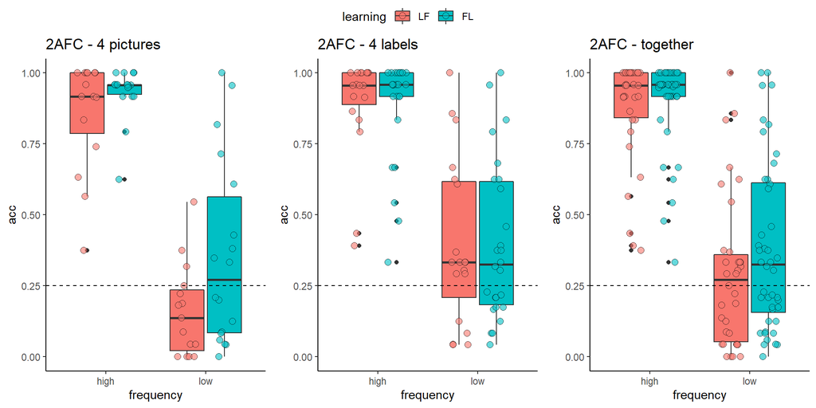

```r
contingency_expe3_clean %>%
  filter(generalizationTest=="labPic") %>%
  group_by(learning, frequency, trialType) %>%
  summarise(mean=mean(resp, na.rm = T),
            sd=sd(resp, na.rm = T),
            count = n()) %>%
  mutate(se = sd / sqrt(count),
         lower_ci = lower_ci(mean, se, count),
         upper_ci = upper_ci(mean, se, count))
```

```
## # A tibble: 8 x 9
## # Groups:   learning, frequency [4]
##   learning frequency trialType        mean    sd count    se lower_ci upper_ci
##   <fct>    <fct>     <fct>           <dbl> <dbl> <int> <dbl>    <dbl>    <dbl>
## 1 LF       l         mismatch-type1  32.3   63.9   225  4.26    23.9     40.7
## 2 LF       l         match          -42.9   67.6   225  4.51   -51.8    -34.0
## 3 LF       h         mismatch-type1 -74.7   49.3   225  3.29   -81.2    -68.2
## 4 LF       h         match           81.0   36.1   225  2.41    76.2     85.7
## 5 FL       l         mismatch-type1   1.54  74.1   270  4.51    -7.34    10.4
## 6 FL       l         match           -5.40  77.0   270  4.69   -14.6      3.83
## 7 FL       h         mismatch-type1 -80.8   40.7   270  2.48   -85.6    -75.9
## 8 FL       h         match           86.2   31.2   270  1.90    82.5     89.9
```

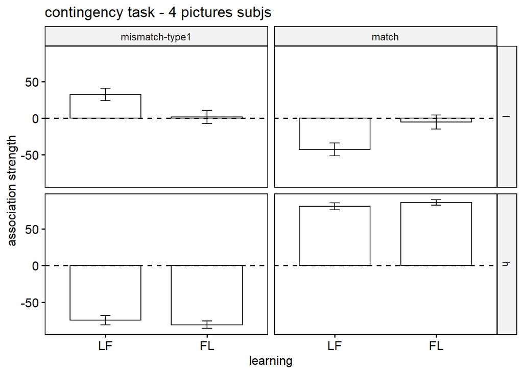

```r
contingency_expe3_clean %>%
  filter(generalizationTest=="picLab") %>%
  group_by(learning, frequency, trialType) %>%
  summarise(mean=mean(resp, na.rm = T),
            sd=sd(resp, na.rm = T),
            count = n()) %>%
  mutate(se = sd / sqrt(count),
         lower_ci = lower_ci(mean, se, count),
         upper_ci = upper_ci(mean, se, count))
```

```
## # A tibble: 8 x 9
## # Groups:   learning, frequency [4]
##   learning frequency trialType        mean    sd count    se lower_ci upper_ci
##   <fct>    <fct>     <fct>           <dbl> <dbl> <int> <dbl>    <dbl>    <dbl>
## 1 LF       l         mismatch-type1   3.42  81.0   285  4.80    -6.02    12.9
## 2 LF       l         match          -15.0   78.8   285  4.67   -24.1     -5.77
## 3 LF       h         mismatch-type1 -76.3   50.0   285  2.96   -82.1    -70.5
## 4 LF       h         match           76.3   48.4   285  2.87    70.6     81.9
## 5 FL       l         mismatch-type1  -4.99  76.7   390  3.89   -12.6      2.65
## 6 FL       l         match          -11.0   75.4   390  3.82   -18.5     -3.53
## 7 FL       h         mismatch-type1 -72.2   49.7   390  2.51   -77.2    -67.3
## 8 FL       h         match           72.1   53.3   390  2.70    66.8     77.4
```

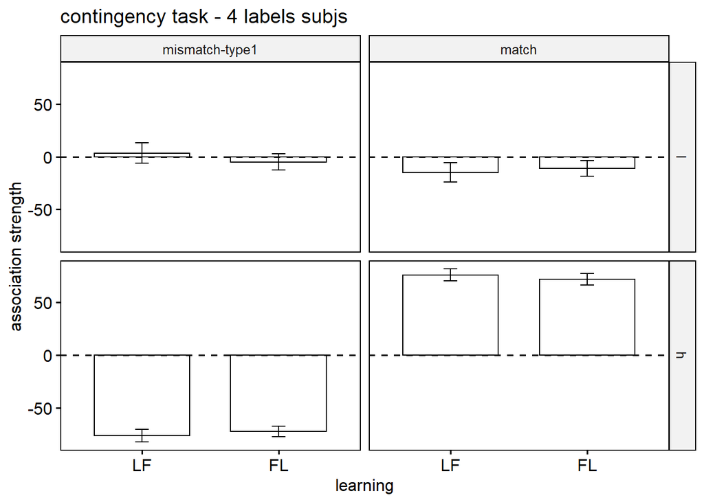

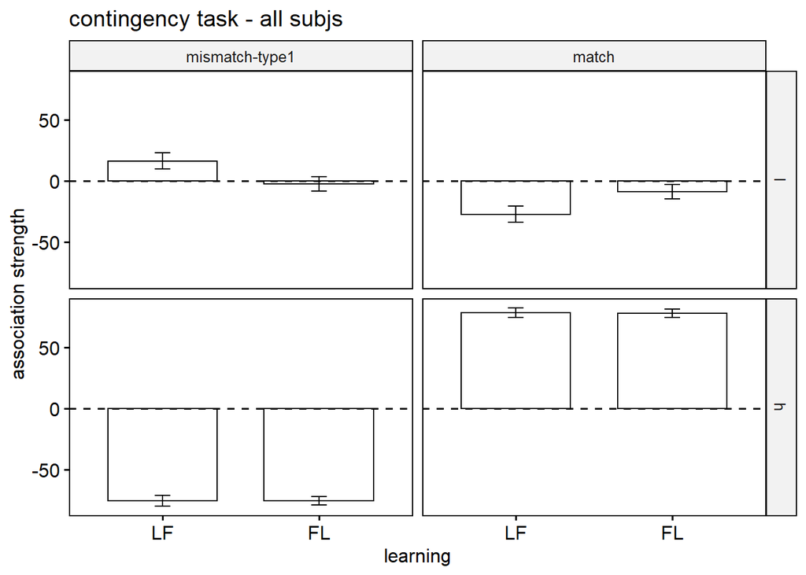